# Reproducible Research: Peer Assessment 1

This assignment answers several questions about a set of walking activity data for an anonymous individual, described in the README file.

## Loading and preprocessing the data

First, let’s load packages we’ll use.

```r
library(dplyr)      #for easier data summaries
library(ggplot2)    #for the histogram
library(lattice)    #for the panel plot
library(lubridate)  #for handling dates
```

Next, read in the data file to a data frame called **activity**.

```r
# tbl_df is a dplyr wrapper around a data frame
# that makes it print only a few rows and only the
# colums that will fit on the screen.

activity<-tbl_df(read.csv(file="activity.csv", head=TRUE))
activity
```

```
## Source: local data frame [17,568 x 3]
##
##    steps       date interval
## 1     NA 2012-10-01        0
## 2     NA 2012-10-01        5
## 3     NA 2012-10-01       10
## 4     NA 2012-10-01       15
## 5     NA 2012-10-01       20
## 6     NA 2012-10-01       25
## 7     NA 2012-10-01       30
## 8     NA 2012-10-01       35
## 9     NA 2012-10-01       40
## 10    NA 2012-10-01       45
## ..   ...        ...      ...
```

As described in the README file, there are 17,568 rows and 3 variables - steps, date, and interval.

Now create a version of the data without the rows that have an NA value for steps. This is not the same thing as the data imputation we will do later. We’re removing the NAs here because making summaries and plots without this handling of NAs doesn’t seem useful. Otherwise, if you just use `na.rm=TRUE` you get a 0 for your summary statistic on a day that has all NAs for steps, which might not be a good characterization of the typical daily activity.

```r
#filter is a dplyr function
activity_no_NA<-filter(activity, !(is.na(steps)))
activity_no_NA
```

```
## Source: local data frame [15,264 x 3]
##
##    steps       date interval
## 1      0 2012-10-02        0
## 2      0 2012-10-02        5
## 3      0 2012-10-02       10
## 4      0 2012-10-02       15
## 5      0 2012-10-02       20
## 6      0 2012-10-02       25
## 7      0 2012-10-02       30
## 8      0 2012-10-02       35
## 9      0 2012-10-02       40
## 10     0 2012-10-02       45
## ..   ...        ...      ...
```

## What is mean total number of steps taken per day?

The **mean and the median are just above 10,000 steps**. Specifically, the **mean=10,770** and the **median=10,760**. Let’s look at more detail.

First, let’s summarize total steps by day.

```r
#%>% is the dplyr data pipeline notation
#Our 2 summary statistics are the total steps for a particular day,
#and the count of (non-NA) observations for that particular day.
stepsByDay<- activity_no_NA %>%
  group_by(Date = as.factor(date)) %>%
  summarise(total = sum(steps), count = n())

head(stepsByDay,10)
```

```
## Source: local data frame [10 x 3]
##
##          Date total count
## 1  2012-10-02   126   288
## 2  2012-10-03 11352   288
## 3  2012-10-04 12116   288
## 4  2012-10-05 13294   288
## 5  2012-10-06 15420   288
## 6  2012-10-07 11015   288
## 7  2012-10-09 12811   288
## 8  2012-10-10  9900   288
## 9  2012-10-11 10304   288
## 10 2012-10-12 17382   288
```

Create a histogram of daily steps.

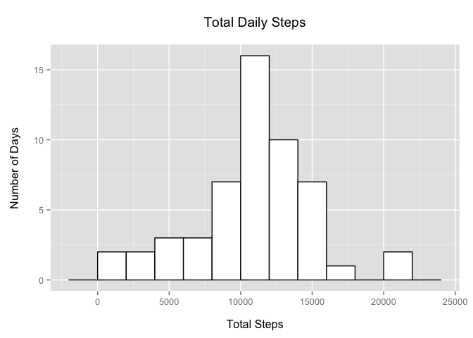

```r
#Set the binwidth to 2000 in order to give a good balance
#between summarizing the data and still seeing enough detail.
stepHisto<- ggplot(stepsByDay, aes(x=total)) +
  geom_histogram(binwidth=2000,color="black", fill="white") +
  labs(title="Total Daily Steps\n ") +
  labs(x = "\nTotal Steps") +
  labs(y = "Number of Days\n")

stepHisto
```

Now let’s compute the mean, the quartiles, and the extremes (min and max).

```r
#get the mean, median, etc. from the 'summary' function in base R.
#We create our own array, DailySteps, by taking the different elements from the
#summary output.

stepsSummary<-summary(stepsByDay$total)
DailySteps<-c(
  as.integer(stepsSummary[4]), #mean
  as.integer(stepsSummary[3]), #median
  as.integer(stepsSummary[1]), #min
  as.integer(stepsSummary[6]), #max
  as.integer(stepsSummary[2]), #1stQuartile
  as.integer(stepsSummary[5])  #3rdQuartile
  )

#We assign names to the array I just created.
names(DailySteps)<-c("Mean", "Median", "Minimum", "Maximum", "1Q", "3Q")
#Make it a data frame so it prints vertically, and maybe I can do more with it later.
DailySteps<-as.data.frame(DailySteps)

DailySteps
```

```
##         DailySteps
## Mean         10770
## Median       10760
## Minimum         41
## Maximum      21190
## 1Q            8841
## 3Q           13290
```

## What is the average daily activity pattern?

First, average the data by interval.

```r
#Use the data from which the NAs were removed.
stepsByInterval<- activity_no_NA %>%
  group_by(Interval = as.factor(interval)) %>%
  summarise(AverageSteps = mean(steps))

head(stepsByInterval,5)
```

```
## Source: local data frame [5 x 2]
##
##   Interval AverageSteps
## 1        0    1.7169811
## 2        5    0.3396226
## 3       10    0.1320755
## 4       15    0.1509434
## 5       20    0.0754717
```

Then, create a plot of the average steps by interval using the summary data just created.

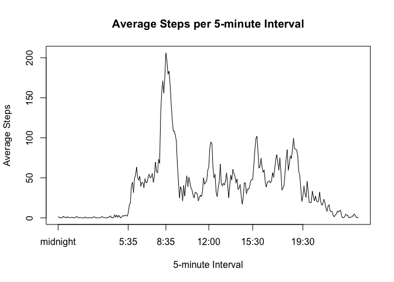

```r
#We will only label some x-axis tickmarks to keep the plot cleaner.
#define which intervals you want to label on the x-axis.
#these were identified by inspecting the stepsByInterval data frame.
tickmarks<-c(1,68,104,145,187,235)
#create human readable labels for the tickmarks.
intervalLabels<-c("midnight","5:35","8:35","12:00","15:30","19:30")

#Use the base plotting system to create a time-series plot.
#I find the base plotting system is easier to use for time-series than ggplot2.
plot(stepsByInterval$AverageSteps, type="l", xaxt='n',
     ylab="Average Steps", xlab="5-minute Interval",main="Average Steps per 5-minute Interval")

#put the tickmarks on the axis with the appropriate labels
axis(1, at=tickmarks, labels = intervalLabels)
```

The **busiest 5-minute interval of the day starts at 8:35am** with an average of just over 206 steps. The code below produces that result.

```r
#Find the interval with the maximum number of steps.
filter(stepsByInterval, AverageSteps == max(AverageSteps))
```

```
## Source: local data frame [1 x 2]
##
##   Interval AverageSteps
## 1      835     206.1698
```

## Imputing missing values

### Total number of missing values in the dataset

There were 8 days in which all 288 observations were NA and no days had fewer NAs than 288, as demonstrated by the following code chunk.

```r
#We're starting with the activity data frame, which is the original data with all the NAs.
TotalNAs<- activity %>%
  group_by(Date = as.factor(date)) %>%
  summarise(TotalNAs = sum(is.na(steps)))

filter(TotalNAs, TotalNAs>0) #show the days where the number of NAs > 0
```

```
## Source: local data frame [8 x 2]
##
##         Date TotalNAs
## 1 2012-10-01      288
## 2 2012-10-08      288
## 3 2012-11-01      288
## 4 2012-11-04      288
## 5 2012-11-09      288
## 6 2012-11-10      288
## 7 2012-11-14      288
## 8 2012-11-30      288
```

The **total number of NAs in the dataset** therefore is 8*288=2304. This can be independently verified by counting the total without regard to grouping them by date as a factor.

```r
TotalNAs2<- activity %>%
  summarise(TotalNAs = sum(is.na(steps)))

TotalNAs2
```

```
## Source: local data frame [1 x 1]
##
##   TotalNAs
## 1     2304
```

### Strategy for handling NAs

The best strategy will be to use the mean for the 5-minute interval, as suggested in the assignment. We’ve already calculated these means earlier and stored them in the **stepsByInterval** data frame. Also, we have already created a data frame that has no NAs called **activity_no_NA**. We also confirmed that the NAs were all within specific days. There were no days that had some NAs and some data values. So, our strategy for creating the data set with imputed values will be to create a data frame with just NAs, replace those NAs with the corresponding 5-minute interval mean, then combine that with the **activity_no_NA** data.

### New dataset from NA strategy.

First we’ll create the data that only contains NAs. There should be 8*288=2304 rows.

```r
#"activity"" is the data frame created by reading in the original data.
activity_all_NA<-filter(activity, (is.na(steps)))
activity_all_NA
```

```
## Source: local data frame [2,304 x 3]
##
##    steps       date interval
## 1     NA 2012-10-01        0
## 2     NA 2012-10-01        5
## 3     NA 2012-10-01       10
## 4     NA 2012-10-01       15
## 5     NA 2012-10-01       20
## 6     NA 2012-10-01       25
## 7     NA 2012-10-01       30
## 8     NA 2012-10-01       35
## 9     NA 2012-10-01       40
## 10    NA 2012-10-01       45
## ..   ...        ...      ...
```

Next we replace the NA data with the corresponding 5-minute interval data. We’ll take advantage of the fact that R recycles values.

```r
#Put the average steps per 5-minute interval, stored in stepsByInterval,
#into the corresponding NA value.  This takes advantage of R's recycling property.
activity_all_NA$steps<-stepsByInterval$AverageSteps
activity_all_NA
```

```
## Source: local data frame [2,304 x 3]
##
##        steps       date interval
## 1  1.7169811 2012-10-01        0
## 2  0.3396226 2012-10-01        5
## 3  0.1320755 2012-10-01       10
## 4  0.1509434 2012-10-01       15
## 5  0.0754717 2012-10-01       20
## 6  2.0943396 2012-10-01       25
## 7  0.5283019 2012-10-01       30
## 8  0.8679245 2012-10-01       35
## 9  0.0000000 2012-10-01       40
## 10 1.4716981 2012-10-01       45
## ..       ...        ...      ...
```

Finally, we combine the imputed data with the no-NA data. We can see that we have 17,568 rows, just like the original data set.

```r
#we use the dplyr efficient rbind function.
imputedActivityData<-rbind_list(activity_all_NA,activity_no_NA)
imputedActivityData
```

```
## Source: local data frame [17,568 x 3]
##
##        steps       date interval
## 1  1.7169811 2012-10-01        0
## 2  0.3396226 2012-10-01        5
## 3  0.1320755 2012-10-01       10
## 4  0.1509434 2012-10-01       15
## 5  0.0754717 2012-10-01       20
## 6  2.0943396 2012-10-01       25
## 7  0.5283019 2012-10-01       30
## 8  0.8679245 2012-10-01       35
## 9  0.0000000 2012-10-01       40
## 10 1.4716981 2012-10-01       45
## ..       ...        ...      ...
```

### Histogram

We’ll re-use our histogram code, but with the imputed data.

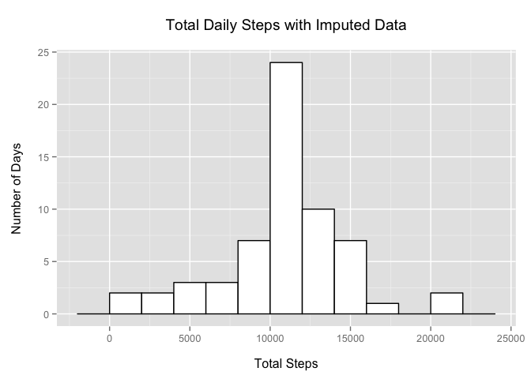

```r
#We need to compute stepsByDayImputed to feed the histogram
stepsByDayImputed<- imputedActivityData %>%
  group_by(Date = as.factor(date)) %>%
  summarise(total = sum(steps), count = n())

#Plot the histogram
stepHisto2<- ggplot(stepsByDayImputed, aes(x=total)) +
  geom_histogram(binwidth=2000,color="black", fill="white") +
  labs(title="Total Daily Steps with Imputed Data\n ") +
  labs(x = "\nTotal Steps") +
  labs(y = "Number of Days\n")

stepHisto2
```

```r
#as we did earlier, use the Base R summary function.
stepsSummaryImputed<-summary(stepsByDayImputed$total)
DailyStepsImputed<-c(
  as.integer(stepsSummaryImputed[4]), #mean
  as.integer(stepsSummaryImputed[3]), #median
  as.integer(stepsSummaryImputed[1]), #min
  as.integer(stepsSummaryImputed[6]), #max
  as.integer(stepsSummaryImputed[2]), #1stQuartile
  as.integer(stepsSummaryImputed[5])  #3rdQuartile
  )

#We assign names to the array I just created.
names(DailyStepsImputed)<-c("Mean", "Median", "Minimum", "Maximum", "1Q", "3Q")

#Make it a data frame so it prints vertically.
DailyStepsImputed<-as.data.frame(DailyStepsImputed)
#combine the non-imputed summary and the imputed summary.
CompareDailySteps<-cbind(DailyStepsImputed,DailySteps)

CompareDailySteps
```

```
##         DailyStepsImputed DailySteps
## Mean                10770      10770
## Median              10770      10760
## Minimum                41         41
## Maximum             21190      21190
## 1Q                   9819       8841
## 3Q                  12810      13290
```

The data show differences in the quartiles (1st, 3rd, and median). The mean, min, and max are the same. Because we imputed mean values, the means weren’t different from the data where NAs were removed. But, the total number of observations differed between the two data sets, which affected the quartiles.

## Are there differences in activity patterns between weekdays and weekends?

Yes, weekdays and weekends differ in some respects. To start, we’ll create two new variables, one that codes the day of the week, and another that codes for weekday and weekend. We’ll also print the unique weekday values in the data along with their weekend/weekday code so that we can check the success of our operation.

```r
#"imputedActivityData" is the activity data with the imputed means we created earlier
#mutate is a dplyr function
#wday is a lubridate function for getting day of the week
imputedActivityData <- mutate(imputedActivityData,
        Day = wday(ymd(date), label=TRUE, abbr=TRUE),
        DayCategory = as.factor(ifelse(Day < "Mon" | Day > "Fri", "Weekend","Weekday")))
# print the unique values for Day along with the weekday/weekend category
# so we can check the success of our operation.
check<-distinct(imputedActivityData,Day)
#use the dplyr arrange function to sort the data by Category and Day
arrange(check[,4:5],DayCategory, Day)
```

```
## Source: local data frame [7 x 2]
##
##     Day DayCategory
## 1   Mon     Weekday
## 2  Tues     Weekday
## 3   Wed     Weekday
## 4 Thurs     Weekday
## 5   Fri     Weekday
## 6   Sun     Weekend
## 7   Sat     Weekend
```

Summarize the data so we can plot it. This is similar to the approach we took earlier with the steps by interval plot, but we’re also grouping the summary by weekday/weekend, in addition to 5 minute interval.

```r
stepsByInterval2<- imputedActivityData %>%
  group_by(Interval = as.factor(interval),DayCategory) %>%
  summarise(AverageSteps = mean(steps))

head(stepsByInterval2,5)
```

```
## Source: local data frame [5 x 3]
## Groups: Interval
##
##   Interval DayCategory AverageSteps
## 1        0     Weekday   2.25115304
## 2        0     Weekend   0.21462264
## 3        5     Weekday   0.44528302
## 4        5     Weekend   0.04245283
## 5       10     Weekday   0.17316562
```

Plot the data so we can compare the weekday and weekend data for average steps per 5 minute interval.

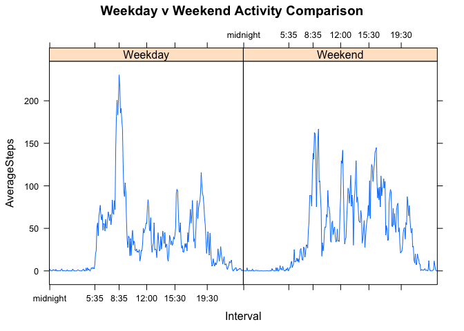

```r
xyplot(AverageSteps ~ Interval | DayCategory,
       data = stepsByInterval2,
       type = "l",
       main="Weekday v Weekend Activity Comparison",
       #we'll use the tickmarks and labels from our earlier interval plot.
       scales = list(x=list(at=tickmarks,labels = intervalLabels)))
```